# Tutorial 1 - Cancer 9x9

Author

Affiliation

Lieven Clement

Ghent University

# 1 Load packages

We load the `msqrob2` package, along with additional packages for data manipulation and visualisation.

```r
library("QFeatures")
library("dplyr")
library("tidyr")
library("ggplot2")
library("msqrob2")
library("stringr")
library("ExploreModelMatrix")
library("MsCoreUtils")
library("matrixStats")
library("patchwork")
library("kableExtra")
library("ComplexHeatmap")
library("purrr")
library("tibble")
library("scater")
```

# 2 Load QFeatures object

```r
(
  qf <- readRDS(url("https://github.com/statOmics/PDA-DIA/raw/refs/heads/main/data/cancer9x9.rds","rb"))
)
```

```
An instance of class QFeatures (type: bulk) with 4 sets:

 [1] peptides_raw: SummarizedExperiment with 26531 rows and 18 columns
 [2] peptides_log: SummarizedExperiment with 26531 rows and 18 columns
 [3] peptides_norm: SummarizedExperiment with 26531 rows and 18 columns
 [4] proteins: SummarizedExperiment with 3506 rows and 18 columns
```

# 3 Data exploration

First assess distribution of marginal protein intensities.

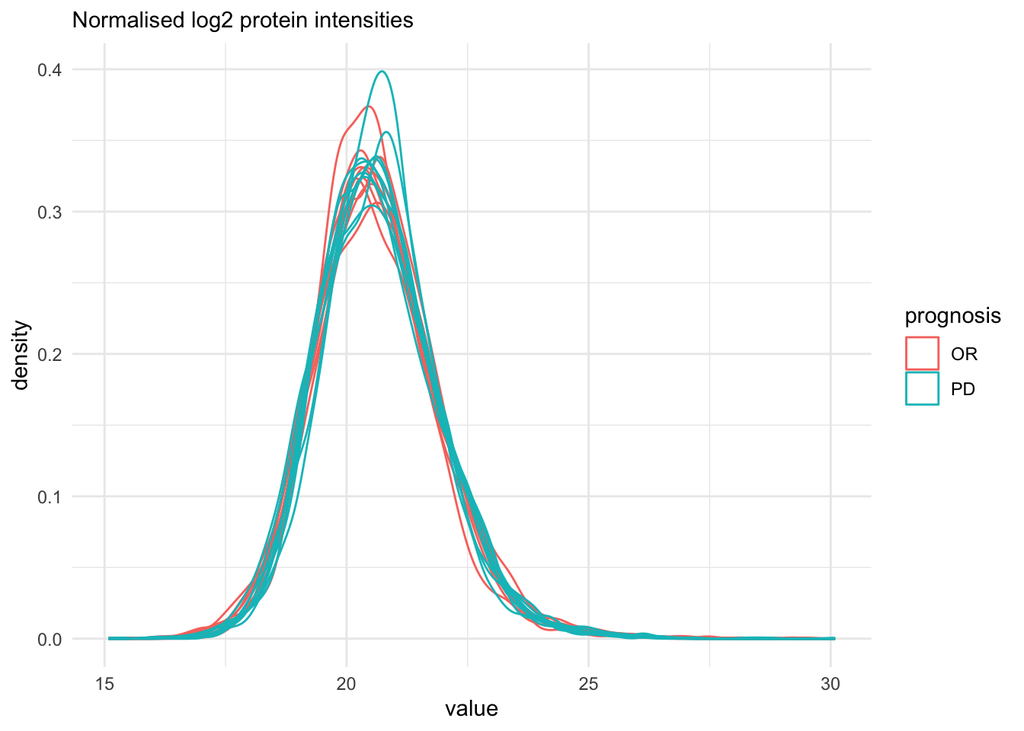

```r
qf[, , "proteins"] |>
    longForm(colvars = colnames(colData(qf))) |>
  data.frame() |>
  filter(!is.na(value)) |>
  ggplot() +
  aes(x = value,
      colour = prognosis,
      group = colname) +
  geom_density() +
  theme_minimal() +
   labs(subtitle = "Normalised log2 protein intensities")
```

Data exploration aims to highlight the main sources of variation in the data prior to data modelling and can pinpoint to outlying or off-behaving samples.

A common approach for data exploration is to perform dimension reduction, such as Multi Dimensional Scaling (MDS). We will first extract the set to explore along the sample annotations (used for plot colouring).

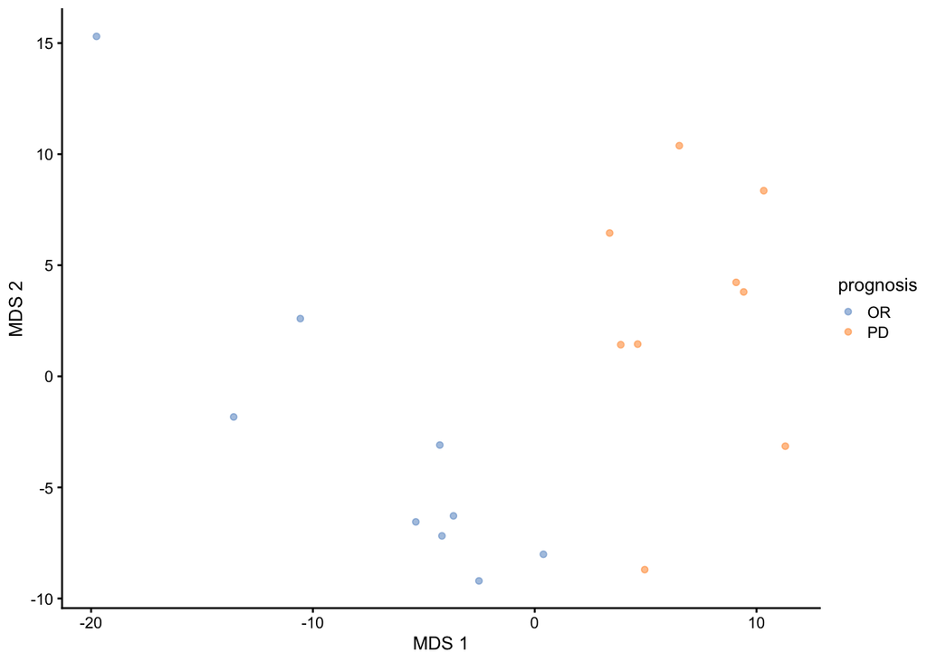

```r
qf |>
  getWithColData("proteins") |>
  as("SingleCellExperiment") |>
  scater::runMDS(exprs_values = 1) |>
  scater::plotMDS(colour_by = "prognosis")
```

# 4 Data Modeling (Robust Regression)

## 4.1 Model estimation

1. We first define the model. We only have one sources of variability in the experiment that we can model, i.e. the association with prognosis.
2. We fit the model to each protein in the `proteins` summarised experiment of the QFeatures object `qf` using the msqrob function.

```r
model <- ~ prognosis

qf <- msqrob(
  qf,
  i = "proteins",
  formula = model,
  robust = TRUE)
```

We enabled M-estimation (`robust = TRUE`) for improved robustness against outliers.

The fitting results are available in the `msqrobModels` column of the `rowData`. More specifically, the modelling output is stored in the `rowData` as a `statModel` object, one model per row (protein). We will see in a later section how to perform statistical inference on the estimated parameters.

```r
models <- rowData(qf[["proteins"]])[["msqrobModels"]]
models[1:3]
```

```
$A0AV96
Object of class "StatModel"
The type is "rlm"
There number of elements is 7

$A0AVT1
Object of class "StatModel"
The type is "rlm"
There number of elements is 7

$A0FGR8
Object of class "StatModel"
The type is "rlm"
There number of elements is 7
```

## 4.2 Inference

To aid defining contrasts, we will visualise the experimental design using the `ExploreModelMatrix` package.

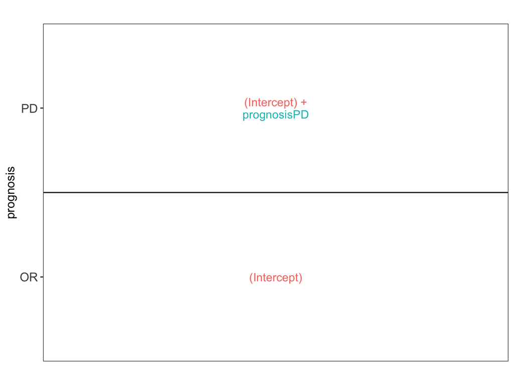

```r
vd <- ExploreModelMatrix::VisualizeDesign(
    sampleData =  colData(qf),
    designFormula = model,
    textSizeFitted = 4
)
vd$plotlist
```

```r
contrast <- "prognosisPD = 0"
(L <- makeContrast(
   contrast,
   parameterNames = colnames(vd$designmatrix)
))
```

```
            prognosisPD
(Intercept)           0
prognosisPD           1
```

We assess the contrast for each protein.

```r
qf <- hypothesisTest(qf, i = "proteins", contrast = L)
```

We extract the results table from the `proteins` summarised experiment in the `qf` object.

```r
inference <-
  msqrobCollect(qf[["proteins"]], L)
```

## 4.3 Report results

We report the results using a results table, volcano plots and heatmaps.

### 4.3.1 Results table

We report all results that are significant at the nominal FDR level of 5%.

1. We define the nominal FDR level
2. We filter the results
3. We arrange them according to statistical significance

```r
alpha  <- 0.05
inference |>
  filter(adjPval < alpha) |>
  arrange(pval) |>
  knitr::kable()
```

|  | logFC | se | df | t | pval | adjPval | contrast | feature |
| --- | --- | --- | --- | --- | --- | --- | --- | --- |
| prognosisPD.P61604 | 2.6041240 | 0.3250551 | 20.64962 | 8.011330 | 0.0000001 | 0.0002967 | prognosisPD | P61604 |
| prognosisPD.P06454 | 3.3789333 | 0.4510993 | 20.88319 | 7.490443 | 0.0000002 | 0.0003938 | prognosisPD | P06454 |
| prognosisPD.Q96K17 | 1.6766684 | 0.2135589 | 16.66846 | 7.851081 | 0.0000005 | 0.0003938 | prognosisPD | Q96K17 |
| prognosisPD.P49006 | 2.2746124 | 0.3101449 | 18.22272 | 7.334031 | 0.0000008 | 0.0003938 | prognosisPD | P49006 |
| prognosisPD.Q8NC51 | 1.6657595 | 0.2363348 | 19.80273 | 7.048305 | 0.0000008 | 0.0003938 | prognosisPD | Q8NC51 |
| prognosisPD.Q13765 | 1.4199990 | 0.2040024 | 19.68369 | 6.960697 | 0.0000010 | 0.0003938 | prognosisPD | Q13765 |
| prognosisPD.O43396 | 1.9230797 | 0.2713492 | 18.75705 | 7.087104 | 0.0000010 | 0.0003938 | prognosisPD | O43396 |
| prognosisPD.P54727 | 1.6173693 | 0.2316137 | 19.14945 | 6.983046 | 0.0000011 | 0.0003938 | prognosisPD | P54727 |
| prognosisPD.Q9NXG2 | 1.7143795 | 0.2540731 | 20.76058 | 6.747584 | 0.0000012 | 0.0003938 | prognosisPD | Q9NXG2 |
| prognosisPD.P07108 | 4.2542023 | 0.4749194 | 11.93903 | 8.957735 | 0.0000012 | 0.0003938 | prognosisPD | P07108 |
| prognosisPD.Q9H299 | 1.9395700 | 0.2921190 | 20.03375 | 6.639657 | 0.0000018 | 0.0005377 | prognosisPD | Q9H299 |
| prognosisPD.Q9GZT3 | 2.0157004 | 0.3200318 | 20.42718 | 6.298438 | 0.0000034 | 0.0009349 | prognosisPD | Q9GZT3 |
| prognosisPD.P63313 | 3.3989709 | 0.4818571 | 14.60186 | 7.053898 | 0.0000045 | 0.0011339 | prognosisPD | P63313 |
| prognosisPD.Q9UBE0 | 1.1997904 | 0.1964488 | 20.65961 | 6.107395 | 0.0000050 | 0.0011339 | prognosisPD | Q9UBE0 |
| prognosisPD.P27797 | 1.4613961 | 0.2399652 | 20.63039 | 6.090033 | 0.0000052 | 0.0011339 | prognosisPD | P27797 |
| prognosisPD.O60635 | -1.8704902 | 0.2634919 | 12.69920 | -7.098852 | 0.0000092 | 0.0018736 | prognosisPD | O60635 |
| prognosisPD.P09496 | 1.4512161 | 0.2534685 | 20.53051 | 5.725430 | 0.0000120 | 0.0022366 | prognosisPD | P09496 |
| prognosisPD.P09012 | 1.8807719 | 0.3119256 | 17.37835 | 6.029553 | 0.0000123 | 0.0022366 | prognosisPD | P09012 |
| prognosisPD.O43765 | 1.0501577 | 0.1847814 | 20.45672 | 5.683244 | 0.0000134 | 0.0023090 | prognosisPD | O43765 |
| prognosisPD.P30084 | 1.7956099 | 0.3160253 | 19.49759 | 5.681854 | 0.0000161 | 0.0026326 | prognosisPD | P30084 |
| prognosisPD.O75368 | 2.2473966 | 0.4029769 | 18.64520 | 5.576987 | 0.0000239 | 0.0036002 | prognosisPD | O75368 |
| prognosisPD.P55327 | 1.7147764 | 0.3130844 | 19.58030 | 5.477042 | 0.0000250 | 0.0036002 | prognosisPD | P55327 |
| prognosisPD.O75223 | 1.8772711 | 0.3465195 | 20.27451 | 5.417506 | 0.0000253 | 0.0036002 | prognosisPD | O75223 |
| prognosisPD.P30085 | 1.2350160 | 0.2354281 | 20.82664 | 5.245830 | 0.0000345 | 0.0046977 | prognosisPD | P30085 |
| prognosisPD.P46108 | 1.6135876 | 0.2911523 | 16.93903 | 5.542075 | 0.0000363 | 0.0047460 | prognosisPD | P46108 |
| prognosisPD.P22307 | 1.3504567 | 0.2562669 | 19.03567 | 5.269727 | 0.0000434 | 0.0053024 | prognosisPD | P22307 |
| prognosisPD.P20042 | 1.0102350 | 0.1962977 | 20.48862 | 5.146443 | 0.0000457 | 0.0053024 | prognosisPD | P20042 |
| prognosisPD.P43490 | 1.4879350 | 0.2846566 | 19.24274 | 5.227123 | 0.0000461 | 0.0053024 | prognosisPD | P43490 |
| prognosisPD.Q15758 | -1.4777359 | 0.2760829 | 17.59084 | -5.352508 | 0.0000471 | 0.0053024 | prognosisPD | Q15758 |
| prognosisPD.P06730 | 2.0005445 | 0.3485479 | 13.91310 | 5.739655 | 0.0000524 | 0.0056267 | prognosisPD | P06730 |

[output cut: 76 more lines]

### 4.3.2 Volcanoplots

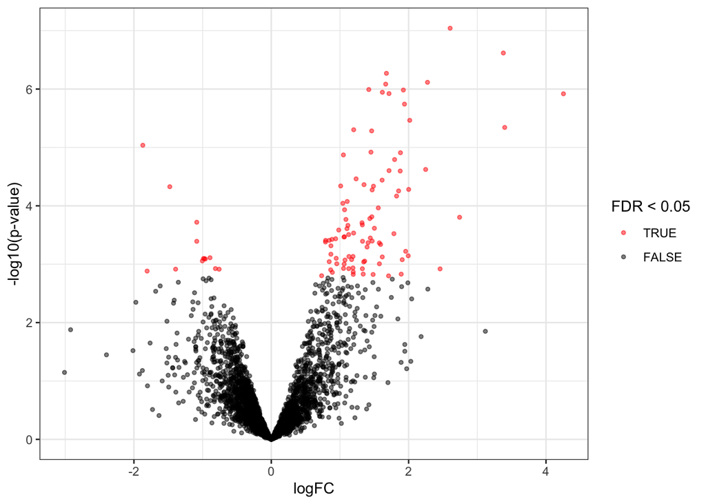

```r
volcanoplot4 <- plot_volcano(inference)
volcanoplot4
```

### 4.3.3 Heatmaps

We make the heatmap as follows

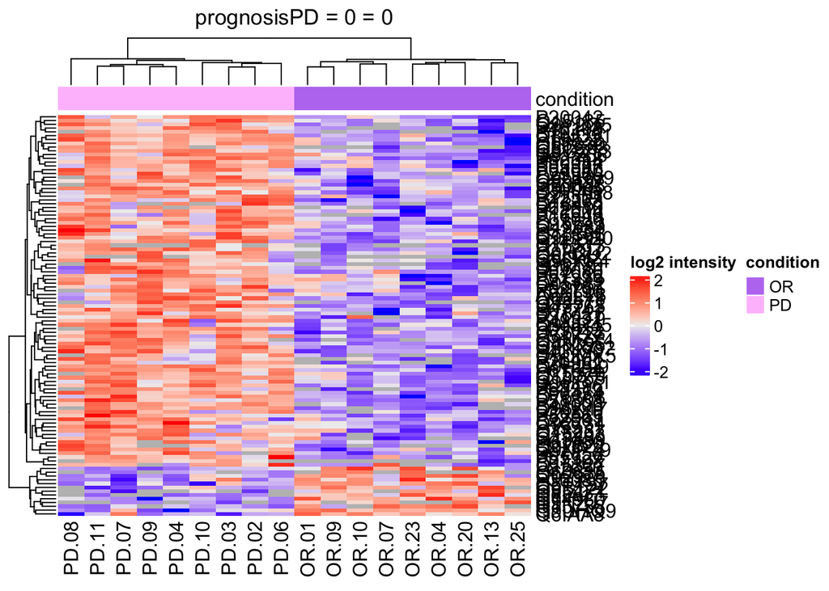

```r
sig <- inference |>
  filter(adjPval < alpha) |>
  arrange(pval) |>
  pull(feature) #1.

se <- getWithColData(qf, "proteins")
quants <- t(scale(t(assay(se[sig,])))) #2.

annotations <- columnAnnotation(
  condition = se$prognosis
) #3.

set.seed(1234) ## annotation colours are randomly generated by default
heatmap <- Heatmap(
                       quants,
                       name = "log2 intensity",
                       top_annotation = annotations,
                       column_title = paste0(contrast, " = 0")
                       ) #4.
heatmap
```

### 4.3.4 Detail plots

We can explore the data for a protein to validate the statistical inference results. For example, let’s explore the normalised precursor and the summarised protein intensities for the protein with the most significant log2 fold change.

```r
(targetProtein <- inference |>
   slice(which.min(pval)) |>
   pull(feature)
)
```

```
[1] "P61604"
```

To obtain the required data, we perform a little data manipulation pipeline:

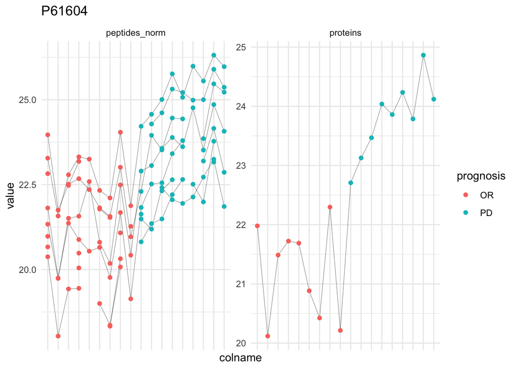

```r
qf[targetProtein, , c("peptides_norm", "proteins")] |> #1
  longForm(colvars = colnames(colData(qf))) |> #2
  data.frame() |>
  ggplot() +
  aes(x = colname,
      y = value) +
  geom_line(aes(group = rowname), linewidth = 0.1) +
  geom_point(aes(colour = prognosis)) +
  facet_wrap(~ assay, scales = "free") +
  ggtitle(targetProtein) +
  theme_minimal() +
  theme(axis.text.x = element_blank())
```

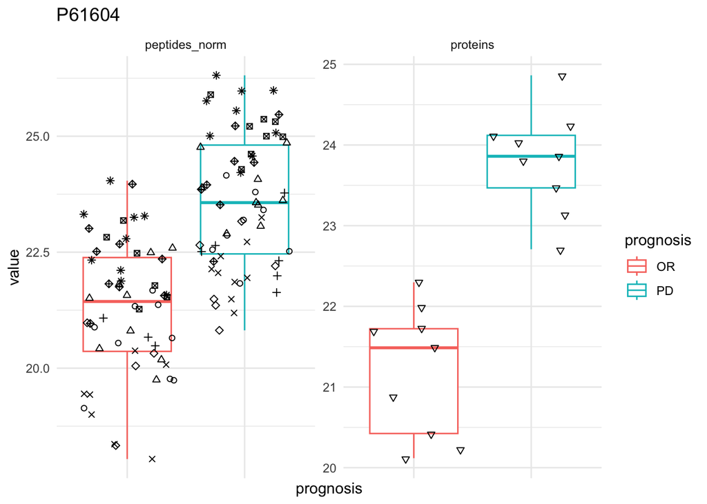

```r
qf[targetProtein, , c("peptides_norm", "proteins")] |> #1
  longForm(colvars = colnames(colData(qf))) |> #2
  data.frame() %>%
  {
  ggplot(.) +
  aes(x = prognosis,
      y = value) +
  geom_boxplot(aes(colour = prognosis)) +
  facet_wrap(~ assay, scales = "free") +
  geom_jitter(aes(shape = rowname)) +
  scale_shape_manual(values = seq_len(dplyr::n_distinct(.$rowname))) +
  ggtitle(targetProtein) +
  theme_minimal() +
  theme(axis.text.x = element_blank()) +
  guides(shape = "none")
  }
```